# ILXSM Update

Sarah Salois, Thomas Swiader

7/12/2024

```r
library(dplyr)
library(ggplot2)
library(sf)
library(patchwork)
lw_data <- read.csv(here::here('data/ilxsm/ILXSM_EntirePull_07-11-2024.csv'))

# Coastal shapefiles
canada <- sf::st_read(here::here('shapefiles/Canada.shp'), quiet = TRUE) %>%
  sf::st_set_crs(4326)
usa <- sf::st_read(here::here('shapefiles/USA.shp'), quiet = TRUE) %>%
  sf::st_set_crs(4326)
sf::sf_use_s2(FALSE)
us.coast = sf::st_union(usa %>% sf::st_as_sf())
ca.coast = sf::st_union(canada %>% sf::st_as_sf())
```

```r
# Make sure all data are in same units, if not convert
# just a check
# unique(lw_data$UNIT_MEASURE)
# "CM" "GM" "MM" "LB"
lbs <- which(lw_data$UNIT_MEASURE == 'LB')
# one rouge tally w/lbs but no param_value_num, so removing
chkme <- lw_data[lbs,]
# lw_data <- lw_data[-lbs,]
# one rouge tally w/lbs this one does have a param_value_num, fixing the unit
lw_data[267392,"UNIT_MEASURE"] <- 'GM'
WT <- which(lw_data$PARAM_TYPE == 'WT') # None, so no need to adjust as below
lw_data <- lw_data %>%
  mutate(PARAM_VALUE_NUM = case_when(PARAM_TYPE == 'ML' & UNIT_MEASURE == 'CM' ~ PARAM_VALUE_NUM * 10,
                            PARAM_TYPE == 'ML' & UNIT_MEASURE == 'MM'~ PARAM_VALUE_NUM,
                           # PARAM_TYPE == 'WT' & UNIT_MEASURE == 'GM' ~ PARAM_VALUE_NUM,
                             PARAM_TYPE == 'OW' & UNIT_MEASURE == 'GM' ~ PARAM_VALUE_NUM))
cm <- which(lw_data$UNIT_MEASURE == 'CM')
#chkme2 <- lw_data[cm,]
lw_data[cm,"UNIT_MEASURE"] <- 'MM'
#unique(lw_data$UNIT_MEASURE)

lw_data$LAND_DATE <-lubridate::dmy(lw_data$LAND_DATE)
lw_data <- lw_data %>%
  mutate(year = lubridate::year(LAND_DATE),
         month = lubridate::month(LAND_DATE),
         week = lubridate::week(LAND_DATE),
         day = lubridate::day(LAND_DATE))

unique_areas <- sort(unique(lw_data$AREA_CODE))

wt <- lw_data %>%
  filter(PARAM_TYPE =='OW') %>%
  rename(weight = PARAM_VALUE_NUM)
ml <- lw_data %>%
  filter(PARAM_TYPE == 'ML') %>%
  rename(length = PARAM_VALUE_NUM)

ml.c <- ml %>% select(LAND_DATE,AREA_CODE,ORGANISM_ID,
                                length,VESSEL_NAME, VTR_SERIAL_NUM)

wt.c <- wt %>% select(LAND_DATE,AREA_CODE,ORGANISM_ID,
                                weight,VESSEL_NAME, VTR_SERIAL_NUM)

lw_paired <- right_join(ml.c, wt.c,
                        by = c('LAND_DATE','AREA_CODE','ORGANISM_ID',
                               'VESSEL_NAME', 'VTR_SERIAL_NUM'))

lw_paired <- na.omit(lw_paired)
lw_paired <- lw_paired %>% relocate(weight, .after = length)

lw_paired <- lw_paired %>%
  mutate(year = lubridate::year(LAND_DATE),
         month = lubridate::month(LAND_DATE),
         week = lubridate::week(LAND_DATE),
         day = lubridate::day(LAND_DATE))
```

```r
## Stat areas
stat.areas <- sf::st_read(here::here('shapefiles/groundfish_stat_areas.shp'),
                          quiet = TRUE) %>%
  sf::st_set_crs(4326)

# Isolate stat areas fished from data frame
unq.stat.areas <- sort(unique(lw_data$AREA_CODE))
ilxsm.stat.areas <- stat.areas[na.omit(stat.areas$Id %in% unq.stat.areas),]

# For multiple polygons - use this!
stat.ctrds <- sf::st_point_on_surface(ilxsm.stat.areas)
# ggplot() +
#   geom_sf(data = ilxsm.stat.areas) +
#   geom_sf(data = stat.ctrds, color = "red", size = 0.1) +
#   theme_void()

# create a dataframe and isolate coordinates
stat.areas.df <- stat.ctrds %>%
  dplyr::mutate(lon = sf::st_coordinates(.)[,1],
                lat = sf::st_coordinates(.)[,2]) %>%
  as.data.frame()
un.df.sa = unique(stat.areas.df$Id)
# extract coordinates and save to squibs data
lw_data$stat.lat <- NA
lw_data$stat.lon <- NA
for (i in 1:length(un.df.sa)){
  tmp <- subset(lw_data, AREA_CODE == un.df.sa[i])
  locs <- which(lw_data$AREA_CODE %in% tmp$AREA_CODE)
  b <- subset(stat.areas.df, Id == un.df.sa[i], select = 'lat')
  c <- subset(stat.areas.df, Id == un.df.sa[i], select = 'lon')
  lw_data[locs,'stat.lat'] <- b$lat
  lw_data[locs,'stat.lon'] <- c$lon
}

# tally by stat area
df_tally_stat <- lw_data %>%
  group_by(AREA_CODE, year) %>%
  summarise(n = length(ORGANISM_ID),
            lon = mean(stat.lon),
            lat = mean(stat.lat))
```

### ILXSM Spatial Extent

Map of Northeast United States Continental Shelf Large Marine Ecosystem (NES LME). Bathymetry is indicated by a dark grey contours. The black polygons overlaid on the bathymetry depict the boundaries of the [Greater Atlantic Region Fisheries Statistical Areas](https://www.fisheries.noaa.gov/resource/map/greater-atlantic-region-statistical-areas). The location of each circle demarks the centroid of the statistical area polygon. Note that each circle is located at the center coordinates of the statistical area and does not represent specific fishing coordinates to ensure confidentiality. The color of the circle indicates the collection year, where yellow = 2021, purple = 2022, magenta = 2023, and peach = 2024. The size of each point represents the number of northern shortfin squid (*Illex illecebrosus*) samples reported through Shortfin Squid Electronic Size Monitoring Pilot Project in the associated statistical area.

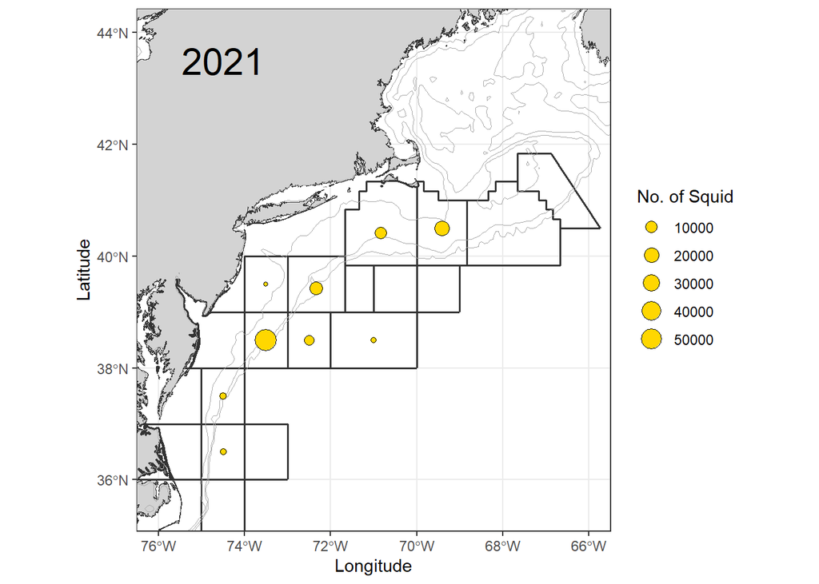

```r
bathy <- marmap::getNOAA.bathy(-80,-58, 33, 46)
bathy = marmap::fortify.bathy(bathy)
#2021
ggplot() +
 geom_sf(data = us.coast %>% st_as_sf(), color = 'gray20', fill = 'lightgrey') +
  geom_sf(data = ca.coast %>% st_as_sf(), color = 'gray20', fill = 'lightgrey') +
  geom_sf(data = ilxsm.stat.areas %>% st_as_sf() ,
          fill = NA, color = 'gray20', lwd = 0.6) +
  geom_contour(data = bathy,
               aes(x=x,y=y,z=-1*z),
               breaks=c(0,50,100,200, Inf),
               size=c(0.3),
               col = 'darkgrey') +
  geom_point(data = df_tally_stat %>% filter(year == 2021),
             aes(x = lon, y = lat, size = n),
             color = 'black', bg = 'gold1',
             pch = 21) +
  labs(size = 'No. of Squid') +
  geom_text()+
  annotate('text', label = '2021', x = -74.5, y = 43.5, size = 8,
           colour = 'black' ) +
  coord_sf(xlim = c(-76,-66.0), ylim = c(35.5,44), datum = sf::st_crs(4326)) +
  xlab('Longitude') +
  ylab('Latitude') +
  theme_bw()
```

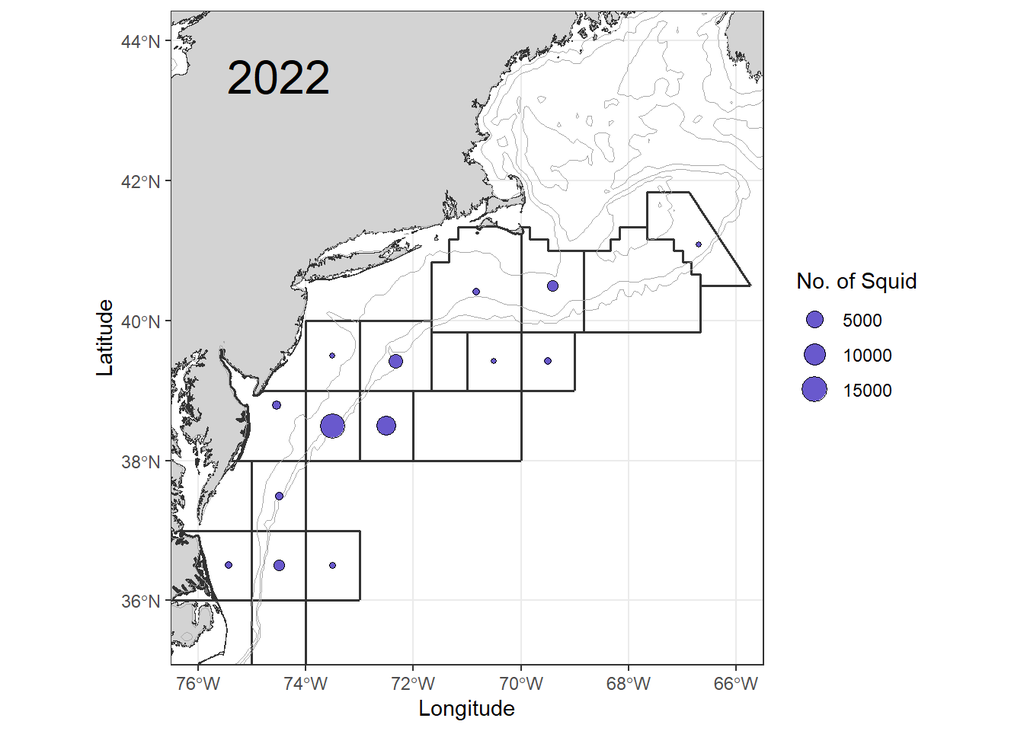

```r
#2022
ggplot() +
 geom_sf(data = us.coast %>% st_as_sf(), color = 'gray20', fill = 'lightgrey') +
  geom_sf(data = ca.coast %>% st_as_sf(), color = 'gray20', fill = 'lightgrey') +
  geom_sf(data = ilxsm.stat.areas %>% st_as_sf() ,
          fill = NA, color = 'gray20', lwd = 0.6) +
  geom_contour(data = bathy,
               aes(x=x,y=y,z=-1*z),
               breaks=c(0,50,100,200, Inf),
               size=c(0.3),
               col = 'darkgrey') +
  geom_point(data = df_tally_stat %>% filter(year == 2022),
             aes(x = lon, y = lat, size = n),
             color = 'black', bg = 'slateblue3',
             pch = 21) +
  labs(size = 'No. of Squid') +
  geom_text()+
  annotate('text', label = '2022', x = -74.5, y = 43.5, size = 8,
           colour = 'black' ) +
  coord_sf(xlim = c(-76,-66.0), ylim = c(35.5,44), datum = sf::st_crs(4326)) +
  xlab('Longitude') +
  ylab('Latitude') +
  theme_bw()
```

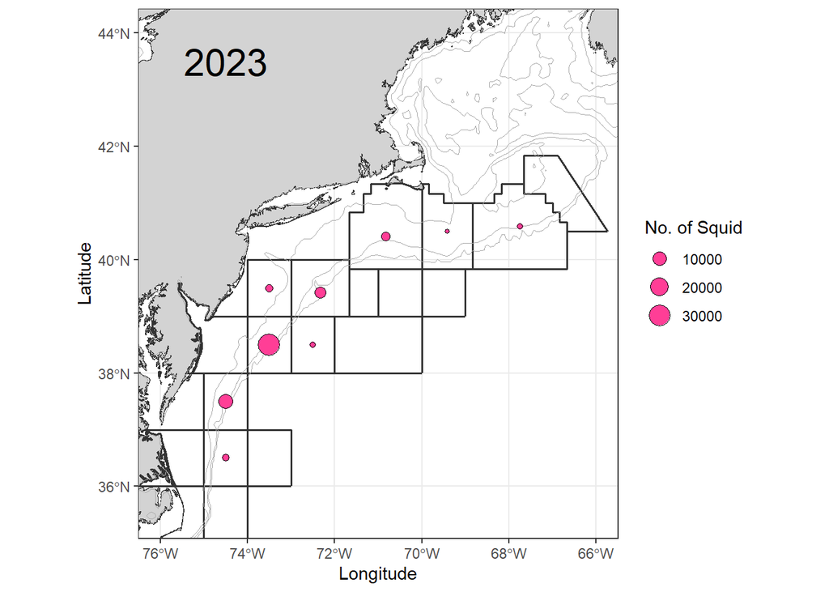

```r
#2023
ggplot() +
 geom_sf(data = us.coast %>% st_as_sf(), color = 'gray20', fill = 'lightgrey') +
  geom_sf(data = ca.coast %>% st_as_sf(), color = 'gray20', fill = 'lightgrey') +
  geom_sf(data = ilxsm.stat.areas %>% st_as_sf() ,
          fill = NA, color = 'gray20', lwd = 0.6) +
  geom_contour(data = bathy,
               aes(x=x,y=y,z=-1*z),
               breaks=c(0,50,100,200, Inf),
               size=c(0.3),
               col = 'darkgrey') +
  geom_point(data = df_tally_stat %>% filter(year == 2023),
             aes(x = lon, y = lat, size = n),
             color = 'black', bg = 'violetred1',
             pch = 21) +
  labs(size = 'No. of Squid') +
  geom_text()+
  annotate('text', label = '2023', x = -74.5, y = 43.5, size = 8,
           colour = 'black' ) +
  coord_sf(xlim = c(-76,-66.0), ylim = c(35.5,44), datum = sf::st_crs(4326)) +
  xlab('Longitude') +
  ylab('Latitude') +
  theme_bw()
```

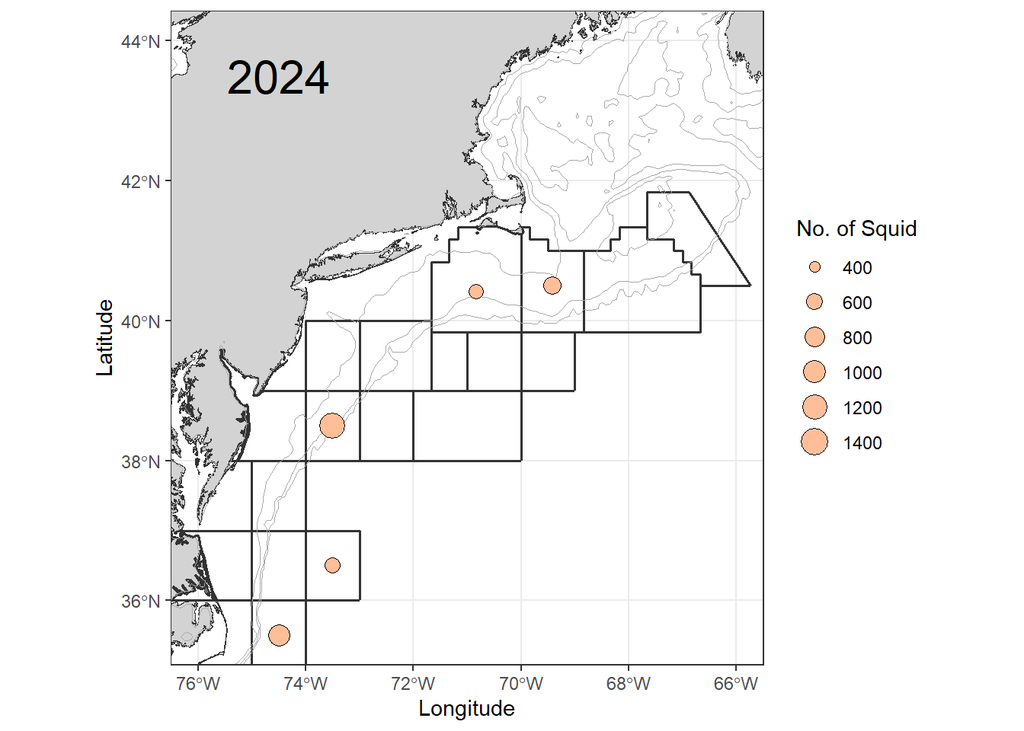

```r
#2024
ggplot() +
 geom_sf(data = us.coast %>% st_as_sf(), color = 'gray20', fill = 'lightgrey') +
  geom_sf(data = ca.coast %>% st_as_sf(), color = 'gray20', fill = 'lightgrey') +
  geom_sf(data = ilxsm.stat.areas %>% st_as_sf() ,
          fill = NA, color = 'gray20', lwd = 0.6) +
  geom_contour(data = bathy,
               aes(x=x,y=y,z=-1*z),
               breaks=c(0,50,100,200, Inf),
               size=c(0.3),
               col = 'darkgrey') +
  geom_point(data = df_tally_stat %>% filter(year == 2024),
             aes(x = lon, y = lat, size = n),
             color = 'black', bg = '#FFBE98',
             pch = 21) +
  labs(size = 'No. of Squid') +
  geom_text()+
  annotate('text', label = '2024', x = -74.5, y = 43.5, size = 8,
           colour = 'black' ) +
  coord_sf(xlim = c(-76,-66.0), ylim = c(35.5,44), datum = sf::st_crs(4326)) +
  xlab('Longitude') +
  ylab('Latitude') +
  theme_bw()
```

### Length x weight across years

> Comparisons of mantle length and body weight across years

Bar Charts:

- (2021): N = 35676
- (2022): N = 26006
- (2023): N = 34121
- (2024): N = 2223

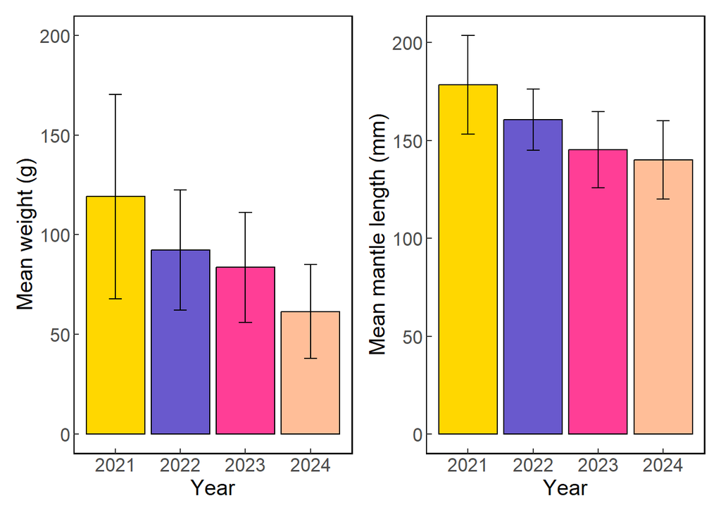

```r
wt_stats <- wt %>%
  group_by(year) %>%
  summarise(mean = mean(weight),
            sd = sd(weight),
            min = min(weight),
            max = max(weight))

ml_stats <- ml %>%
  group_by(year) %>%
  summarise(mean = mean(length),
            sd = sd(length),
            min = min(length),
            max = max(length))

wt_stats$param <- 'weight'
ml_stats$param <- 'mantle_length'


ilxsm_stats <- rbind(wt_stats, ml_stats)
ilxsm_stats$conf_interval <- (1.96*ilxsm_stats$sd)
# Labels outside bars: vjust = -0.5, Inside bars:  vjust = 1.6,
p1 = ggplot(data = wt_stats, aes(x = year, y = mean)) +
  geom_bar(stat ='identity', fill = c('gold1','slateblue3','violetred1', '#FFBE98'),
           col = 'black') +
  ylab('Mean weight (g)') +
  xlab('Year') +
  ylim(0,200) +
  geom_errorbar(aes(ymin = mean - sd, ymax = mean + sd), width=.2,
                position=position_dodge(.9)) +
  ecodata::theme_ts()
p1 = p1 +  theme(text = element_text(size = 14),
            axis.text = element_text(size = 13),
            axis.title = element_text(size = 15),
            axis.ticks.length = unit(-1.4, "mm"))

p2 = ggplot(data = ml_stats, aes(x = year, y = mean)) +
  geom_bar(stat ='identity', fill = c('gold1','slateblue3','violetred1', '#FFBE98'),
           col = 'black') +
  ylab('Mean mantle length (mm)') +
  xlab('Year') +
  geom_errorbar(aes(ymin = mean - sd, ymax = mean + sd), width=.2,
                position=position_dodge(.9)) +
   ecodata::theme_ts()
p2 = p2 +  theme(text = element_text(size = 14),
                 axis.text = element_text(size = 13),
                 axis.title = element_text(size = 15),
                 axis.ticks.length = unit(-1.4, "mm"))



p1 + p2
```

2d Histograms:

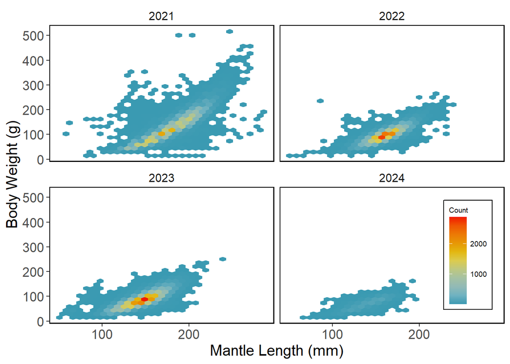

```r
#
# Consolidate dataset to only samples with paired weight/length values

# COlor palettes
pal <- wesanderson::wes_palette("Zissou1", 21, type = "continuous")
# 2d histogram with default option
# ggplot(lw_paired, aes(x=length, y=weight)) +
#   geom_bin2d() +
#   theme_bw()

# # Bin size control + color palette
# gd = ggplot(lw_paired, aes(x=length, y=weight)) +
#   geom_bin2d(bins = 70) +
#   scale_fill_gradientn(colours=pal) +
#   xlab('Mantle Length (mm)') +
#   ylab('Body Weight (g)') +
#   theme_bw()
# gd + theme(text = element_text(size = 14),
#            axis.text = element_text(size = 13),
#            axis.title = element_text(size = 15))



g3 = ggplot(lw_paired,
            aes(x=length, y=weight)) +
  geom_hex() +
  scale_fill_gradientn(colours=pal) +
  xlab('Mantle Length (mm)') +
  ylab('Body Weight (g)') +
  labs(fill = 'Count') +
  ecodata::theme_facet() +
  facet_wrap(~year)
g3 + theme(text = element_text(size = 14),
           axis.text = element_text(size = 13),
           axis.title = element_text(size = 15),
           legend.position = c(0.92, 0.23),
           legend.background = element_rect(fill = "white", color = "black"),
           legend.title = element_text(size = 7),
           legend.text = element_text(size = 7))
```

### 2024 ILXSM data

Weekly distributions of northern shortfin squid (Illex illecebrosus) body weight (in grams) and mantle length (in millimeters) samples for 2024.

The figures below represent the size of squid over time, where squid weight (or length) increases from left to right, with specific weight (or length) values labeled along the horizontal line (axis) under the ridge (peach area). The height of the ridge relates to the number of squid at the corresponding weight on the horizontal axis.

- For instance, the greater the height at a given weight, the more squid are found at that weight.
- The wider the base of the ridge, the wider range of weights of the squid sampled, thus the more variable the sizes collected that week were.

The ridgeplots with color gradients represent the empirical cumulative density function for the distribution. Here, the probabilities are mapped onto color.

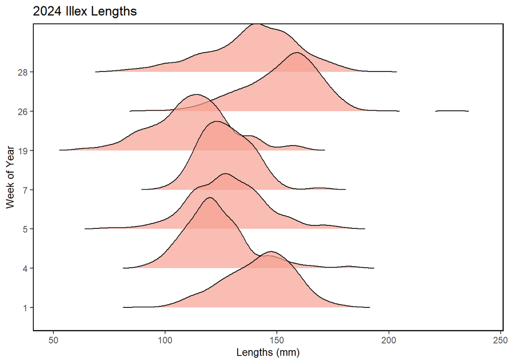

```r
# Lengths
ggplot(ml %>% filter(year == 2024), aes(x = length, y = factor(week))) +
    ggridges::geom_density_ridges(alpha = 0.7, rel_min_height = 0.001, fill='#f6a192') +
  labs(title = '2024 Illex Lengths',
       x = 'Lengths (mm)', y = 'Week of Year') +
  ecodata::theme_ts()
```

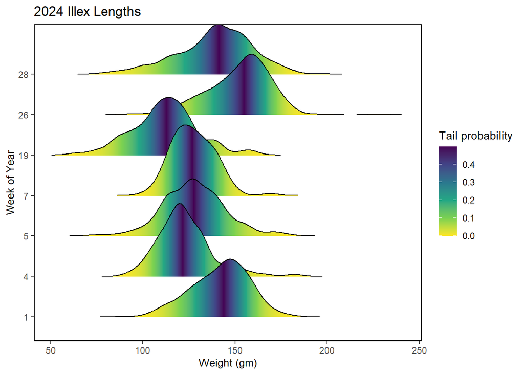

```r
ggplot(ml %>% filter(year == 2024), aes(x = length, y = factor(week),
                                           fill = 0.5 - abs(0.5 - stat(ecdf))))  +
  ggridges::stat_density_ridges(calc_ecdf = TRUE, rel_min_height = 0.0001,
                      geom = "density_ridges_gradient") +
  labs(title = '2024 Illex Lengths',
       x = 'Weight (gm)', y = 'Week of Year') +
  scale_fill_viridis_c(name = 'Tail probability', direction = -1) +
  ecodata::theme_ts()
```

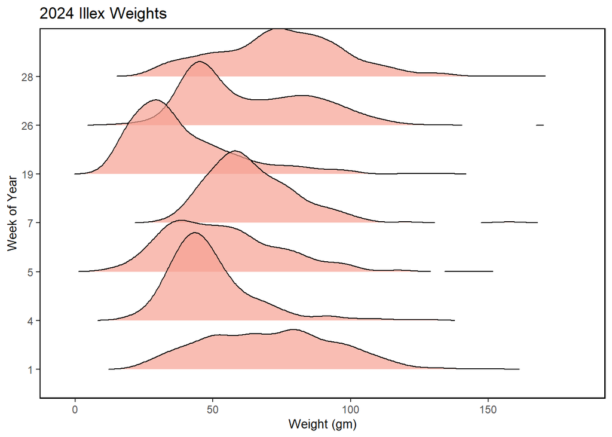

```r
# Weight
ggplot(wt %>% filter(year == 2024), aes(x = weight, y = factor(week))) +
   ggridges::geom_density_ridges(alpha = 0.7, rel_min_height = 0.001,
                                           fill='#f6a192') +
  labs(title = '2024 Illex Weights',
       x = 'Weight (gm)', y = 'Week of Year') +
  ecodata::theme_ts()
```

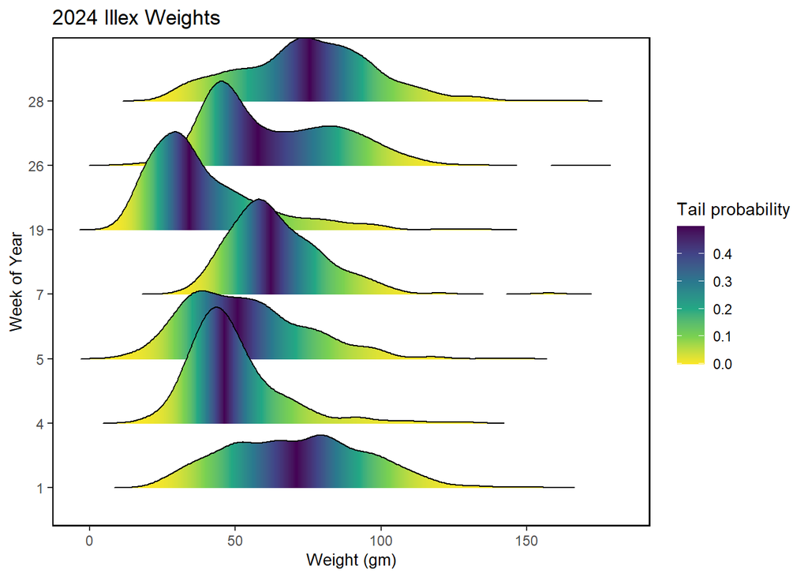

```r
ggplot(wt %>% filter(year == 2024), aes(x = weight, y = factor(week),
                                           fill = 0.5 - abs(0.5 - stat(ecdf))))  +
  ggridges::stat_density_ridges(calc_ecdf = TRUE, rel_min_height = 0.0001,
                      geom = "density_ridges_gradient") +
  labs(title = '2024 Illex Weights',
       x = 'Weight (gm)', y = 'Week of Year') +
  scale_fill_viridis_c(name = 'Tail probability', direction = -1) +
  ecodata::theme_ts()
```